# 145 PyTorch Tricks

# Trick #2 (important)

PyTorch Hooks

PyTorch hook is a tool that we can *register* to any **tensor** or **nn.Module** during our computation so that we can monitor what is going on with our `forward` and `backward` loops.  
The `forward` is not refered to `nn.Module.forward` bu the `torch.Autograd.Function` object that is the `grad_fn` of a **tensor**.  
Notice, that a `nn.Module` like `nn.Linear` can have multiple `forward` invocations. It's output is created by two operations, $Y = W*X+B$, *addition* and *multiplication* and thus there will be two `forward` calls.

## Hook types

1. The Forward Hook
2. The Backward Hook

A forward hook is excuted during the forward pass, while the backward hook is executed when `backward` function is called both of which are *functions* of `Autograd.Funciton` object.

A hook in PyTorch is basically a function, with a very specific signature. When we say a hook is executed, in reality, we are talkingabout this function being executed.  
`grad` is basically the value contained in the `grad` attribute of the tensor **after** `backward` is called. The function is not supposed to modify it's argument. It must either return `None` or a Tensor which will be used in place of `grad` for further gradient computations.  
The below example clarifies this point:

```python
import torch
a = torch.ones(10)
a.requires_grad
```

```
False
```

```python
a.requires_grad = True
a.requires_grad
```

```
True
```

```python
b = 2*a
b.requires_grad
```

```
True
```

```python
print(a.is_leaf)
print(b.is_leaf)
```

```
True
False
```

Since `b` is not a **leaf Variable**, its `grad` will by degault be destroyed during computation.  
We can used `b.retain_grad()` to ask PyTorch to retain its `grad`

```python
b.retain_grad()
```

```python
c = b.mean()
print(f"requires_grad: {c.requires_grad}")
print(f"is_lead: {c.is_leaf}")
```

```
requires_grad: True
is_lead: False
```

```python
# pretend c is the loss being computed
c.backward()
print(a.grad, b.grad)
```

```
tensor([0.2000, 0.2000, 0.2000, 0.2000, 0.2000, 0.2000, 0.2000, 0.2000, 0.2000,
        0.2000]) tensor([0.1000, 0.1000, 0.1000, 0.1000, 0.1000, 0.1000, 0.1000, 0.1000, 0.1000,
        0.1000])
```

```python
a = torch.ones(10)
a.requires_grad = True
b = 2*a
b.retain_grad()
b.register_hook(lambda x:print(x))
b.mean().backward() # pretend the mean of b is the loss we want to back-prop
```

```
tensor([0.1000, 0.1000, 0.1000, 0.1000, 0.1000, 0.1000, 0.1000, 0.1000, 0.1000,
        0.1000])
```

Here we can see that, the print out is exactly the same result by using **hook** on `b`, and the `lambda` function automatically take the `b.grad` as input.  
This gives us a sense that hook is tracking.

```python
print(a.grad, b.grad)
```

```
tensor([0.2000, 0.2000, 0.2000, 0.2000, 0.2000, 0.2000, 0.2000, 0.2000, 0.2000,
        0.2000]) tensor([0.1000, 0.1000, 0.1000, 0.1000, 0.1000, 0.1000, 0.1000, 0.1000, 0.1000,
        0.1000])
```

There are several uses of functionality as above:

```python
# to demonstrate
a = torch.ones(10)
a.requires_grad = True
b = 2*a
b.retain_grad()
b.mean().backward()

print(a.grad, b.grad)
```

```
tensor([0.2000, 0.2000, 0.2000, 0.2000, 0.2000, 0.2000, 0.2000, 0.2000, 0.2000,
        0.2000]) tensor([0.1000, 0.1000, 0.1000, 0.1000, 0.1000, 0.1000, 0.1000, 0.1000, 0.1000,
        0.1000])
```

```python
b.grad *= 2
print(a.grad, b.grad) # Note that in this case, a's grad needs to be updated mannually
```

```
tensor([0.2000, 0.2000, 0.2000, 0.2000, 0.2000, 0.2000, 0.2000, 0.2000, 0.2000,
        0.2000]) tensor([0.2000, 0.2000, 0.2000, 0.2000, 0.2000, 0.2000, 0.2000, 0.2000, 0.2000,
        0.2000])
```

## Hooks for nn.Module objects

For **backward hook**: `hook(module, grad_input, grad_output)`

For **forward hook**: `hook(module, input, output)`

```python
import torch.nn as nn
class myNet(nn.Module):
    def __init__(self):
        super().__init__()
        self.conv = nn.Conv2d(3,10,2, stride=2) # (8-2+0)/2+1 = 4
        self.relu = nn.ReLU()
        self.flatten = lambda x: x.view(-1)
        self.fc1  = nn.Linear(160,5)

    def forward(self, x):
        x = self.relu(self.conv(x))
        return self.fc1(self.flatten(x))
```

```python
Net = myNet()
summary(Net,torch.zeros(1,3,8,8))
```

```
=======================================================
         Kernel Shape   Output Shape Params Mult-Adds
Layer
0_conv  [3, 10, 2, 2]  [1, 10, 4, 4]  130.0     1.92k
1_relu              -  [1, 10, 4, 4]      -         -
2_fc1        [160, 5]            [5]  805.0     800.0
-------------------------------------------------------
                      Totals
Total params           935.0
Trainable params       935.0
Non-trainable params     0.0
Mult-Adds              2.72k
=======================================================
```

| Layer | Kernel Shape | Output Shape | Params | Mult-Adds |
| --- | --- | --- | --- | --- |
| 0_conv | [3, 10, 2, 2] | [1, 10, 4, 4] | 130.0 | 1920.0 |
| 1_relu | - | [1, 10, 4, 4] | NaN | NaN |
| 2_fc1 | [160, 5] | [5] | 805.0 | 800.0 |

```python
def hook_fn(m,i,o):
    print(m)
    print("---------Input Grad----------")

    for grad in i:
        try:
            print(grad.shape)
        except AttributeError:
            print("None found for input Gradient")

    print("--------Output Grad----------")
    for grad in o:
        try:
            print(grad.shape)
        except AttributeError:
            print("None found for output Gradient")
    print("\n")
```

```python
Net.named_modules
```

```
<bound method Module.named_modules of myNet(
  (conv): Conv2d(3, 10, kernel_size=(2, 2), stride=(2, 2))
  (relu): ReLU()
  (fc1): Linear(in_features=160, out_features=5, bias=True)
)>
```

```python
Net.conv.register_backward_hook(hook_fn)
```

```
<torch.utils.hooks.RemovableHandle at 0x7fc70953ce80>
```

```python
Net.fc1.register_backward_hook(hook_fn)
```

```
<torch.utils.hooks.RemovableHandle at 0x7fc709536b00>
```

```python
inp = torch.rand(1,3,8,8)
out = Net(inp)
out
```

```
tensor([ 0.1495, -0.0683,  0.1981,  0.0851, -0.0905], grad_fn=<AddBackward0>)
```

```python
# pretend we have the following as loss
(1-out.mean()).backward()
```

```
Linear(in_features=160, out_features=5, bias=True)
---------Input Grad----------
torch.Size([5])
torch.Size([5])
--------Output Grad----------
torch.Size([5])


Conv2d(3, 10, kernel_size=(2, 2), stride=(2, 2))
---------Input Grad----------
None found for input Gradient
torch.Size([10, 3, 2, 2])
torch.Size([10])
--------Output Grad----------
torch.Size([1, 10, 4, 4])
```

Note that, the `Linear layer` gets called first because the backward pass actually go through it first and then backprop to the `conv layer`

We have:

1. torch.autograd.Variable.register_hook (Python method, in Automatic differentiation package)
2. torch.nn.Module.register_backward_hook (Python method, in torch.nn)
3. torch.nn.Module.register_forward_hook

The first `register_hook`，is for any **Variable**. It's essentially a **callback** function that is going to be executed every time when `Autograd` gradient is computed.  
While `Module.register_backward_hook` & `n.Module.register_forward_hook` are for `nn.Module` object and their `hook_fn` shoud take torch:  
`def hook_fn(m, i, o):` where `i` refers to input and `o` refers to output

### An example

Using `named_parameters` function we can accomplish `gradient modifying/clipping`.  
The following example does two things:

1. Turn gradients of linear biases into zero while back-prop (no updates for biase)
2. Make sure that for no gradient going to `conv layer` is less than 0 (all positive)

```python
class myNet(nn.Module):
    def __init__(self):
        super().__init__()
        self.conv = nn.Conv2d(3,10,2,stride=2)
        self.relu = nn.ReLU()
        self.flatten = lambda x: x.view(-1)
        self.fc1  = nn.Linear(160,5)
    def forward(self,x):
        x = self.relu(self.conv(x))
        x.register_hook(lambda grad: torch.clamp(grad, min=0)) # minimun back-prop gradient of value 0

        # print whether there is any negative grad
        x.register_hook(lambda grad: print("Gradients less than zero:", bool((grad<0).any())))

        return self.fc1(self.flatten(x))
```

```python
net = myNet()
```

```python
for name, param in net.named_parameters():
    print(name)
```

```
conv.weight
conv.bias
fc1.weight
fc1.bias
```

```python
for name, param in net.named_parameters():
    if 'fc' in name and 'bias' in name:
        print(name, param, sep='\n')
```

```
fc1.bias
Parameter containing:
tensor([-0.0190, -0.0193, -0.0728,  0.0082,  0.0160], requires_grad=True)
```

```python
for name, param in net.named_parameters():
    if 'fc' in name and 'bias' in name:
        # assign zero to bias grad with identical dimensions
        param.register_hook(lambda grad: torch.zeros_like(grad))
```

```python
out = net(torch.randn(1,3,8,8))
```

```python
(1-out).mean().backward()
```

```
Gradients less than zero: False
```

```python
print(f'the bias for linear layer is: {net.fc1.bias.grad}')
```

```
the bias for linear layer is: tensor([0., 0., 0., 0., 0.])
```

# Trick #3 (important)

`pack_padded_sequence` & `pad_packed_sequence` often used together dynamic RNNs

```python
import torch
from torch import nn
from torch.nn.utils.rnn import pack_padded_sequence, pad_packed_sequence
```

```python
# Create a tensor with variable length sequences and pads (25)
seqs = torch.LongTensor([[0, 1, 2, 3, 25, 25, 25],
                         [4, 5, 25, 25, 25, 25, 25],
                         [6, 7, 8, 9, 10, 11, 25]])
```

```python
# Store lengths of the actual sequences, ignoring padding(25)
# These are the points up to which we want the RNN to process the sequence
seq_lens = torch.LongTensor([4,3,6]) # number of non-trivial elements in each row
```

```python
seq_lens, sort_ind = seq_lens.sort(dim=0, descending=True)
seq_lens, sort_ind
```

```
(tensor([6, 4, 3]), tensor([2, 0, 1]))
```

```python
seqs = seqs[sort_ind]
seqs
```

```
tensor([[ 6,  7,  8,  9, 10, 11, 25],
        [ 0,  1,  2,  3, 25, 25, 25],
        [ 4,  5, 25, 25, 25, 25, 25]])
```

```python
# Create an embedding layer, with 0 vectors for the pads
embeds = nn.Embedding(num_embeddings=26,
                      embedding_dim=10,
                      padding_idx=25)
```

```python
lstm = nn.LSTM(10, 50, bidirectional=False, batch_first=True)
```

```python
# WITHOUT dynamic batching
embeddings = embeds(seqs)
print(embeddings.size())
out_static, _ = lstm(embeddings)
out_static.size()
```

```
torch.Size([3, 7, 10])
```

```
torch.Size([3, 7, 50])
```

```python
# The number of timesteps in the output will be the same as the total padded timesteps in the input,
# since the LSTM computed over the pads
assert out_static.size(1) == embeddings.size(1)
```

```python
# Look at the output at a timestep that we know is a pad
print(out_static[1,-1])
```

```
tensor([ 0.0821, -0.0592, -0.0492,  0.0023, -0.0777, -0.0576, -0.0531,  0.1315,
         0.0021,  0.0473,  0.0195,  0.0764, -0.1129, -0.0334,  0.0724,  0.1498,
        -0.0529, -0.0625, -0.0379,  0.0425,  0.0015,  0.1318,  0.0448, -0.0354,
         0.1645, -0.0835,  0.0134,  0.0614,  0.0697,  0.0223,  0.0131,  0.0646,
        -0.0725, -0.0345,  0.0158, -0.1179,  0.0900,  0.0378, -0.1458,  0.0356,
         0.0207, -0.0591, -0.0921, -0.0226,  0.0078,  0.0157,  0.0773,  0.0889,
        -0.0189,  0.0382], grad_fn=<SelectBackward>)
```

Now let's try the same process with **Dynamic Batching**

```python
# Pack the sequence
packed_seqs = pack_padded_sequence(embeddings, seq_lens.tolist(), batch_first=True)
print(f'the values in the seq_lens: {seq_lens.tolist()}, with the effective sum of {sum(seq_lens.tolist())}')
embeddings.shape,packed_seqs.data.size()
```

```
the values in the seq_lens: [6, 4, 3], with the effective sum of 13
```

```
(torch.Size([3, 7, 10]), torch.Size([13, 10]))
```

```python
out_dynamic, _ = lstm(packed_seqs)
out_dynamic.data.size()
```

```
torch.Size([13, 50])
```

```python
out_dynamic, lens = pad_packed_sequence(out_dynamic, batch_first=True)
out_dynamic.size(), lens
```

```
(torch.Size([3, 6, 50]), tensor([6, 4, 3]))
```

Note that here, `out_dynamic` is padded in shape of `[3,6,50]` instead of `[3,7,50]` because we know we can discard one pad from all rows to make it even more compact.  
In short, `6` is the longest sequence length in all batches.

```python
assert out_dynamic.size(1) != embeddings.size(1)
print(out_dynamic.shape)
```

```
torch.Size([3, 6, 50])
```

```python
# Look at the output at a timestep that we know is a pad
print(out_dynamic[1, -1])
```

```
tensor([0., 0., 0., 0., 0., 0., 0., 0., 0., 0., 0., 0., 0., 0., 0., 0., 0., 0., 0., 0., 0., 0., 0., 0.,
        0., 0., 0., 0., 0., 0., 0., 0., 0., 0., 0., 0., 0., 0., 0., 0., 0., 0., 0., 0., 0., 0., 0., 0.,
        0., 0.], grad_fn=<SelectBackward>)
```

Final note:

- `pack_padded_sequence` removes pads, flattens by timestep, and keeps track of **effective batch_size** at each timestep
- The RNN computes only on the effective batch size "b_t" at each timestep while save computation from computing *pads*
- This is why we sort, so that top "b_t" rows at timestep "t" are aligned with the top "b_t"" outputs from timestep "t-1"

# Trick #4

Torchviz to visualize PyTorch execution graphs and traces

```python
!pip install torchviz
```

```
     |████████████████████████████████| 51kB 5.4MB/s
```

### Let's start with a basic example(base MLP model)

```python
import torch
from torch import nn
from torchviz import make_dot, make_dot_from_trace
```

```python
model = nn.Sequential()
model.add_module('W0', nn.Linear(8,16))
model.add_module('tanh', nn.Tanh())
model.add_module('W1', nn.Linear(16,1))

inp = torch.randn(1,8)

make_dot(model(inp), params = dict(model.named_parameters()))
```

[figure not shown]

The method is built for directed graphs of PyTorch operations, built during **forward** propagation and showing which operations will be called on **backward**.  
It omits subgraphs which do not require gradients.

### Visualiza AlexNet

```python
from torchvision.models import AlexNet

model = AlexNet()
```

```python
x = torch.randn(1,3,227,227).requires_grad_(True)
y = model(x)
make_dot(y, params = dict(list(model.named_parameters()) + [('x',x)]))
```

[figure not shown]

```python
import torch
import torchvision.models as models
from Utils import *

# Create SSD300 with pretrained weights in the base-architecture
n_classes = 20
model = SSD300(n_classes)
```

```
Loaded base model with pre-trained weights
```

```python
x = torch.randn(1,3,300,300)
y = model(x)
dot = make_dot(y, params = dict(list(model.named_parameters())))
```

```python
dot.render('VGG300_BN.gv', view=True)
```

```
'VGG300_BN.gv.pdf'
```

```python
from google.colab import drive
drive.mount('/content/drive')
```

[output not shown]

# Trick #5

[Awesome PyTorch list](https://github.com/bharathgs/Awesome-pytorch-list)

This is a truly awesome repo full of practical tutorials that implements various state-of-the-art deep learning techniques using PyTorch including:

1. NLP & Speech Processing
2. Computer Vision
3. Probabilistic/Generative Libraries
4. Other libraries
5. Paper implementations

Basically a good place to look into when starting a new project to check for relevant realization techniques.  
Since deep learning is such a fast developing fielding, if it weren't for the reason that this repo stoped getting updated 2 years ago, it should be #1 on this list.

# Trick #6

**AdaBound optimizer**  
Finally, AdaBound is available in PyTorch. One of the most powerful optimizer that out performs Adam in some cases with super fast convergence rate. Definely, something you would want to try out when fast prototyping.  
The method is based on [Adaptive Gradient Methods with Dynamic Bound of Learning Rate](https://openreview.net/forum?id=Bkg3g2R9FX).In Proc. of ICLR 2019.

```python
## implementation
optimizer = adabound.AdaBound(model.parameters(), lr=1e-3, final_lr=0.1)
```

As described in the paper, AdaBound is an optimizer that behavces like **Adam** at the beginning of the training, and gradually transforms to SGD at the end. In this way, it can **combines the benefits of adaptive methods, viz. fast initial process, and the good final generalization properties of SGD.**  
The `final_lr` parameter indicates **Adabound** would transforms to an SGD with this learninig rate. In common cases, a default final learning rate of `0.1` can achieve relatively good and statble results on *unseen data*.  
This method is not very sensitive to it's hyperparameters. *See Appendix G of the paper for more details*

# Trick #7

Flatten layer in PyTorch

```python
import torch.nn as nn
class Flatten(nn.Module):
    def __init__(self):
        super(Flatten, self).__init__()

    def forward(self, x):
        return x.view(x.size(0), -1)
```

# Trick #8

Expand_as in PyTorch for broadcasting

```python
import torch
import torch.nn as nn
```

```python
a = torch.tensor([1,2,3])
b = torch.tensor([[1,2,3],[4,5,6],[7,8,9]])
```

```python
c = a.expand_as(b)
c
```

```
tensor([[1, 2, 3],
        [1, 2, 3],
        [1, 2, 3]])
```

```python
d = a+b
d # here a will be broadcasted before compute addition with b
```

```
tensor([[ 2,  4,  6],
        [ 5,  7,  9],
        [ 8, 10, 12]])
```

# Trick #9

**FastAI** listify

```python
x = [1,2,3]
y = torch.arange(12)
```

```python
x
```

```
[1, 2, 3]
```

```python
y
```

```
tensor([ 0,  1,  2,  3,  4,  5,  6,  7,  8,  9, 10, 11])
```

```python
from fastai.train import listify
z = listify(x)
z
```

```
[1, 2, 3]
```

```python
z = listify(1,x)
z
```

```
[1, 1, 1]
```

```python
a = listify(1,y)
a
```

```
[1, 1, 1, 1, 1, 1, 1, 1, 1, 1, 1, 1]
```

```python
b = listify('good',x)
b
```

```
['good', 'good', 'good']
```

# Trick #10

In_place

```python
# an example of NOT in-place
a = torch.randn(1)
b = torch.randn(1)
id(a)
```

```
139797812240960
```

```python
id(b)
```

```
139797812224360
```

```python
# an example of in-place
c = torch.randn(1)
d = torch.randn(1)
id(c)
```

```
139797812367792
```

```python
id(d)
```

```
139797812492616
```

```python
c += d
id(c)   # not changed because in-place
```

```
139797812367792
```

```python
# another example of in-place
e = torch.randn(1)
f = torch.randn(1)
id(e)
```

```
139797812423848
```

```python
id(f)
```

```
139797812422336
```

```python
e.add_(f)
id(e)       # this case, in-place
```

```
139797812423848
```

In PyTroch _ as postfix means inplace.  
The variable will be modified and stored in the same memory place without creating a no vacancy for storage

# Trick #11

`AdaptiveConcatPool2d`

```python
import torch.nn as nn
# nn.AdaptiveAvgPool2d??
```

```python
class AdaptiveConcatPool2d(nn.Module):
    def __init__(self, sz=1):
        super().__init__()
        self.dropout_size = sz
        self.ap = nn.AdaptiveAvgPool2d(sz)
        self.mp = nn.AdaptiveMaxPool2d(sz)
    def forward(self, x):
        return torch.cat([self.ap(x), self.mp(x)],dim=1)
```

```python
x = torch.tensor([
                  [
                   [1.,2.,3.],
                   [1.,2.,3.],
                   [1.,2.,4.]
                  ],
                  [
                   [1.,2.,3.],
                   [1.,2.,3.],
                   [1.,2.,5.]
                  ],
                  [
                   [1.,2.,3.],
                   [1.,2.,3.],
                   [1.,2.,3.]
                  ]
])
x.shape
```

```
torch.Size([3, 3, 3])
```

```python
A = nn.AdaptiveAvgPool2d(1) # specify the output size
print(A(x).shape)
A(x)
```

```
torch.Size([3, 1, 1])
```

[output not shown]

```python
M = nn.AdaptiveMaxPool2d(1)
M(x)
```

```
tensor([[[4.]],

        [[5.]],

        [[3.]]])
```

```python
A = nn.AdaptiveAvgPool2d((1,3))
print(A(x).shape)
A(x)
```

```
torch.Size([3, 1, 3])
```

```
tensor([[[1.0000, 2.0000, 3.3333]],

        [[1.0000, 2.0000, 3.6667]],

        [[1.0000, 2.0000, 3.0000]]])
```

```python
C = AdaptiveConcatPool2d(1)
C(x)
```

```
tensor([[[2.1111],
         [4.0000]],

        [[2.2222],
         [5.0000]],

        [[2.0000],
         [3.0000]]])
```

# Trick #12

logsumexp

```python
a = torch.zeros(1,3)
a
```

```
tensor([[0., 0., 0.]])
```

```python
b = torch.logsumexp(input=a,dim=1,keepdim=False)
b
```

```
tensor([1.0986])
```

```python
zero = torch.tensor([0],dtype=torch.float)
torch.log(torch.exp(zero)+torch.exp(zero)+torch.exp(zero))
```

```
tensor([1.0986])
```

```python
c = torch.ones(1,3)
c
```

```
tensor([[1., 1., 1.]])
```

```python
d = torch.logsumexp(c,dim=1)
d
```

```
tensor([2.0986])
```

```python
one = torch.tensor([1], dtype=torch.float)
torch.log(torch.exp(one)+torch.exp(one)+torch.exp(one))
```

```
tensor([2.0986])
```

# Trick 13

Named_children

```python
import torch
import torch.nn as nn
```

```python
class Net(nn.Module):
    def __init__(self):
        super(Net, self).__init__()
        self.conv1 = nn.Conv2d( 1, 10, 3)
        self.conv2 = nn.Conv2d(10, 20, 3)
        self.conv2_dropout = nn.Dropout2d(p=0.5)
        self.fc1   = nn.Linear(320, 50)
        self.fc2   = nn.Linear(50, 10)

    def forward(self, x):
        pass
```

```python
x = Net()
```

```python
for l, name in x.named_children():
    print(f"layer {l} is: {name}")
```

```
layer conv1 is: Conv2d(1, 10, kernel_size=(3, 3), stride=(1, 1))
layer conv2 is: Conv2d(10, 20, kernel_size=(3, 3), stride=(1, 1))
layer conv2_dropout is: Dropout2d(p=0.5, inplace=False)
layer fc1 is: Linear(in_features=320, out_features=50, bias=True)
layer fc2 is: Linear(in_features=50, out_features=10, bias=True)
```

# Trick #14

`torch.addcmul()`

```python
x = torch.ones(1,3)
y = torch.ones(3,1)
z = torch.ones(1,1)*2
x, y, z
```

```
(tensor([[1., 1., 1.]]), tensor([[1.],
         [1.],
         [1.]]), tensor([[2.]]))
```

```python
# torch.addcmul(input, value=1, tensor1, tensor2)
a = torch.addcmul(z, 0.5, x, y) # z + 0.5*x*y
a
```

```
tensor([[2.5000, 2.5000, 2.5000],
        [2.5000, 2.5000, 2.5000],
        [2.5000, 2.5000, 2.5000]])
```

```python
x,y
```

```
(tensor([[1., 1., 1.]]), tensor([[1.],
         [1.],
         [1.]]))
```

```python
x*y
```

```
tensor([[1., 1., 1.],
        [1., 1., 1.],
        [1., 1., 1.]])
```

```python
z + 0.5*x*y
```

```
tensor([[2.5000, 2.5000, 2.5000],
        [2.5000, 2.5000, 2.5000],
        [2.5000, 2.5000, 2.5000]])
```

# Trick #15

`torch.permute` used to re-arrange the dimension of a given tensor

```python
x = torch.randn(3,4)
x
```

```
tensor([[ 0.2616,  0.5046, -0.1475,  0.4465],
        [-0.1938,  0.4212, -0.4747,  0.7031],
        [ 1.9922,  2.0265, -0.9237, -1.6005]])
```

```python
y = x.permute(1,0)
y
```

```
tensor([[ 0.2616, -0.1938,  1.9922],
        [ 0.5046,  0.4212,  2.0265],
        [-0.1475, -0.4747, -0.9237],
        [ 0.4465,  0.7031, -1.6005]])
```

```python
a = torch.randn(3,4,5,6,7,8)
a.shape
```

```
torch.Size([3, 4, 5, 6, 7, 8])
```

```python
b = a.permute(2,1,0,4,3,5)
b.size()
```

```
torch.Size([5, 4, 3, 7, 6, 8])
```

# Trick #16

Creating a concise four layer CNN

```python
def conv_block(in_channels, out_channels):
    return nn.Sequential(nn.Conv2d(in_channels, out_channels, 2),
                         nn.BatchNorm2d(out_channels),
                         nn.ReLU(),
                         nn.MaxPool2d(kernel_size=2))
```

```python
class ConvNet(nn.Module):
    def __init__(self, x_dim=3, hid_dim=64, z_dim=64):
        super().__init__()
        self.encoder = nn.Sequential(
            conv_block(x_dim,   hid_dim),
            conv_block(hid_dim, hid_dim),
            conv_block(hid_dim, hid_dim),
            conv_block(hid_dim, z_dim)
        )
    def forward(self, x):
        x = self.encoder(x)
        x = nn.MaxPool2d(5)(x)
        x = x.view(x.size(0), -1)  # flatten while only retain the batch_size dimenison
        return x
```

```python
net = ConvNet()
net
```

```
ConvNet(
  (encoder): Sequential(
    (0): Sequential(
      (0): Conv2d(3, 64, kernel_size=(2, 2), stride=(1, 1))
      (1): BatchNorm2d(64, eps=1e-05, momentum=0.1, affine=True, track_running_stats=True)
      (2): ReLU()
      (3): MaxPool2d(kernel_size=2, stride=2, padding=0, dilation=1, ceil_mode=False)
    )
    (1): Sequential(
      (0): Conv2d(64, 64, kernel_size=(2, 2), stride=(1, 1))
      (1): BatchNorm2d(64, eps=1e-05, momentum=0.1, affine=True, track_running_stats=True)
      (2): ReLU()
      (3): MaxPool2d(kernel_size=2, stride=2, padding=0, dilation=1, ceil_mode=False)
    )
    (2): Sequential(
      (0): Conv2d(64, 64, kernel_size=(2, 2), stride=(1, 1))
      (1): BatchNorm2d(64, eps=1e-05, momentum=0.1, affine=True, track_running_stats=True)
      (2): ReLU()
      (3): MaxPool2d(kernel_size=2, stride=2, padding=0, dilation=1, ceil_mode=False)
    )
    (3): Sequential(
      (0): Conv2d(64, 64, kernel_size=(2, 2), stride=(1, 1))
      (1): BatchNorm2d(64, eps=1e-05, momentum=0.1, affine=True, track_running_stats=True)
      (2): ReLU()
      (3): MaxPool2d(kernel_size=2, stride=2, padding=0, dilation=1, ceil_mode=False)
    )
  )
)
```

# Trick #17

The mechanism behind `torch.dropout()`

```python
y = torch.ones(3,3)
y
```

```
tensor([[1., 1., 1.],
        [1., 1., 1.],
        [1., 1., 1.]])
```

```python
D = nn.Dropout(0)
D(y)
```

```
tensor([[1., 1., 1.],
        [1., 1., 1.],
        [1., 1., 1.]])
```

```python
D = nn.Dropout(0.5)
D(y)
```

```
tensor([[0., 2., 0.],
        [2., 2., 0.],
        [0., 2., 0.]])
```

```python
D = nn.Dropout(1)
D(y)
```

```
tensor([[0., 0., 0.],
        [0., 0., 0.],
        [0., 0., 0.]])
```

```python
D = nn.Dropout(0.3)
D(y)
```

```
tensor([[0.0000, 0.0000, 0.0000],
        [1.4286, 0.0000, 1.4286],
        [1.4286, 1.4286, 1.4286]])
```

```python
D = nn.Dropout(0.8)
D(y)
```

```
tensor([[0., 0., 5.],
        [5., 0., 5.],
        [5., 0., 0.]])
```

Final note, the output value will be `original/(1-p)`

# Trick #18

Creating mini-batch

```python
import torch
x = torch.randn(3,128,128)
x.shape
```

```
torch.Size([3, 128, 128])
```

```python
t = x.unsqueeze(0)
t.shape
```

```
torch.Size([1, 3, 128, 128])
```

```python
u = x[None,:]
u.shape
```

```
torch.Size([1, 3, 128, 128])
```

```python
v = x[None]
v.shape
```

```
torch.Size([1, 3, 128, 128])
```

# Trick #19

Look into `torch.nn.ReLU()`

```python
x = torch.randn(3,3)
x
```

```
tensor([[-1.1243,  0.5653,  0.3340],
        [-1.7015, -0.8263,  0.2759],
        [ 0.5675,  0.8615, -0.4378]])
```

```python
y = nn.ReLU()
print(y(x)) # All negative values goes to zero, inplance default is False
x
```

```
tensor([[0.0000, 0.5653, 0.3340],
        [0.0000, 0.0000, 0.2759],
        [0.5675, 0.8615, 0.0000]])
```

```
tensor([[-1.1243,  0.5653,  0.3340],
        [-1.7015, -0.8263,  0.2759],
        [ 0.5675,  0.8615, -0.4378]])
```

```python
y = nn.ReLU(inplace=True)
print(y(x))
x
```

```
tensor([[0.0000, 0.5653, 0.3340],
        [0.0000, 0.0000, 0.2759],
        [0.5675, 0.8615, 0.0000]])
```

```
tensor([[0.0000, 0.5653, 0.3340],
        [0.0000, 0.0000, 0.2759],
        [0.5675, 0.8615, 0.0000]])
```

# Trick #20

change torch.tensor **type**

```python
x = torch.randn(3,3)
x.dtype
```

```
torch.float32
```

```python
x = x.type(torch.long)
x.dtype
```

```
torch.int64
```

```python
x = torch.randn(3,3).type(torch.float)
x.dtype
```

```
torch.float32
```

```python
x = torch.ones(3,3, dtype=torch.long)
x.dtype
```

```
torch.int64
```

# Trick #21

`L1Loss` vs `MSELoss`

```python
x = torch.randn(1)
x
```

```
tensor([-0.8117])
```

```python
y = torch.ones(1)
y
```

```
tensor([1.])
```

```python
z = nn.L1Loss()
z(x,y)
```

```
tensor(1.8117)
```

```python
abs(x-y)
```

```
tensor([1.8117])
```

```python
a = nn.MSELoss()
a(x,y)
```

```
tensor(3.2822)
```

```python
pow((x-y),2)
```

```
tensor([3.2822])
```

# Trick #22

Sigmoid in PyTorch

```python
x = torch.randn(1)
x
```

```
tensor([-1.1949])
```

```python
y = nn.Sigmoid()
y(x)
```

```
tensor([0.2324])
```

```python
import math
(1/(1+math.exp(-x)))
```

```
0.23237839781597944
```

```python
z = torch.ones(3,4)
z
```

```
tensor([[1., 1., 1., 1.],
        [1., 1., 1., 1.],
        [1., 1., 1., 1.]])
```

```python
y(z)
```

```
tensor([[0.7311, 0.7311, 0.7311, 0.7311],
        [0.7311, 0.7311, 0.7311, 0.7311],
        [0.7311, 0.7311, 0.7311, 0.7311]])
```

```python
z = torch.randn(3,4)
z
```

```
tensor([[ 0.0480,  0.2540,  1.5722,  0.3227],
        [-1.0730,  0.8581, -1.3591, -0.2922],
        [ 0.6118,  0.5229,  0.0910,  1.1228]])
```

```python
y(z)
```

```
tensor([[0.5120, 0.5632, 0.8281, 0.5800],
        [0.2548, 0.7023, 0.2044, 0.4275],
        [0.6484, 0.6278, 0.5227, 0.7545]])
```

# Trick #23

Softmax in Pytorch

```python
x = torch.randn(2,2)
x
```

```
tensor([[-1.0719, -0.8291],
        [-0.3748,  0.0375]])
```

```python
y = nn.Softmax()
a = y(x);a
```

```
tensor([[0.4396, 0.5604],
        [0.3983, 0.6017]])
```

```python
a[0][0]+a[0][1]
```

```
tensor(1.)
```

```python
a[1][0]+a[1][1]
```

```
tensor(1.)
```

# Trick #24

`nn.ModuleList`

```python
x = nn.ModuleList([nn.Dropout(0.5),
                   nn.ReLU()])
```

```python
x
```

```
ModuleList(
  (0): Dropout(p=0.5, inplace=False)
  (1): ReLU()
)
```

```python
y = torch.randn(3,3)
y
```

```
tensor([[ 0.6233, -0.3660,  0.8597],
        [-1.4992, -0.3499,  1.3273],
        [ 0.5832, -1.0665, -1.6803]])
```

```python
t = x[0](y);t  # performed dropout, and value modified as original/(1-0.5)
```

```
tensor([[ 0.0000, -0.7321,  1.7194],
        [-2.9985, -0.6999,  2.6546],
        [ 0.0000, -2.1329, -0.0000]])
```

```python
r = x[1](t);r   # performed ReLU
```

```
tensor([[0.0000, 0.0000, 1.7194],
        [0.0000, 0.0000, 2.6546],
        [0.0000, 0.0000, 0.0000]])
```

# Trick #25

`nn.Linear`

```python
x = torch.randn(2);x
```

```
tensor([0.0459, 0.0121])
```

```python
a = nn.Linear(2,1);a
```

```
Linear(in_features=2, out_features=1, bias=True)
```

```python
a.weight, a.bias
```

```
(Parameter containing:
 tensor([[0.1052, 0.3337]], requires_grad=True), Parameter containing:
 tensor([-0.3842], requires_grad=True))
```

```python
a(x)
```

```
tensor([-0.3754], grad_fn=<AddBackward0>)
```

```python
x@a.weight.t()+a.bias
```

```
tensor([-0.3754], grad_fn=<AddBackward0>)
```

# Trick #26

`torch.mean()`

```python
x = torch.FloatTensor([[1,2,3,4],[5,6,7,8]])
x.shape
```

```
torch.Size([2, 4])
```

```python
y = x.mean()
y
```

```
tensor(4.5000)
```

```python
y = x.mean(dim=1, keepdim=True);y
```

```
tensor([[2.5000],
        [6.5000]])
```

```python
y = x.mean(dim=1, keepdim=False);y
```

```
tensor([2.5000, 6.5000])
```

```python
y.shape
```

```
torch.Size([2])
```

```python
x = torch.randn(3,4,5)
x.shape
```

```
torch.Size([3, 4, 5])
```

```python
y = x.mean(dim=1, keepdim=False);y.shape
```

```
torch.Size([3, 5])
```

```python
y = x.mean(dim=1, keepdim=True);y.shape
```

```
torch.Size([3, 1, 5])
```

```python
y
```

```
tensor([[[ 0.1030, -0.2823, -0.3783, -0.4649, -0.4580]],

        [[-0.0760, -0.3777, -0.3589,  0.6745,  0.0425]],

        [[ 0.5953, -0.7010, -0.4688,  0.1781, -0.3393]]])
```

# Trick #27

Use `dropblock` in PyTorch

```python
!pip install dropblock
```

```python
x = torch.ones(5,5,5,5);x.shape
```

```
torch.Size([5, 5, 5, 5])
```

```python
import dropblock
y = dropblock.DropBlock2D(drop_prob=0.5, block_size=2)
y(x)    # dropout 2x2 size blocks with chance of 50%
```

```
tensor([[[[1.4706, 0.0000, 0.0000, 1.4706, 0.0000],
          [0.0000, 0.0000, 0.0000, 0.0000, 0.0000],
          [0.0000, 0.0000, 0.0000, 0.0000, 0.0000],
          [1.4706, 0.0000, 0.0000, 1.4706, 1.4706],
          [1.4706, 1.4706, 1.4706, 0.0000, 0.0000]],

         [[1.4706, 0.0000, 0.0000, 1.4706, 0.0000],
          [0.0000, 0.0000, 0.0000, 0.0000, 0.0000],
          [0.0000, 0.0000, 0.0000, 0.0000, 0.0000],
          [1.4706, 0.0000, 0.0000, 1.4706, 1.4706],
          [1.4706, 1.4706, 1.4706, 0.0000, 0.0000]],

         [[1.4706, 0.0000, 0.0000, 1.4706, 0.0000],
          [0.0000, 0.0000, 0.0000, 0.0000, 0.0000],
          [0.0000, 0.0000, 0.0000, 0.0000, 0.0000],
          [1.4706, 0.0000, 0.0000, 1.4706, 1.4706],
          [1.4706, 1.4706, 1.4706, 0.0000, 0.0000]],

         [[1.4706, 0.0000, 0.0000, 1.4706, 0.0000],
          [0.0000, 0.0000, 0.0000, 0.0000, 0.0000],
          [0.0000, 0.0000, 0.0000, 0.0000, 0.0000],
          [1.4706, 0.0000, 0.0000, 1.4706, 1.4706],
          [1.4706, 1.4706, 1.4706, 0.0000, 0.0000]],

         [[1.4706, 0.0000, 0.0000, 1.4706, 0.0000],
          [0.0000, 0.0000, 0.0000, 0.0000, 0.0000],
          [0.0000, 0.0000, 0.0000, 0.0000, 0.0000],
          [1.4706, 0.0000, 0.0000, 1.4706, 1.4706],
          [1.4706, 1.4706, 1.4706, 0.0000, 0.0000]]],


        [[[1.4706, 1.4706, 0.0000, 0.0000, 1.4706],
          [1.4706, 1.4706, 0.0000, 0.0000, 1.4706],
          [1.4706, 1.4706, 1.4706, 1.4706, 1.4706],
          [1.4706, 1.4706, 1.4706, 1.4706, 1.4706],
          [1.4706, 1.4706, 1.4706, 1.4706, 1.4706]],

         [[1.4706, 1.4706, 0.0000, 0.0000, 1.4706],
          [1.4706, 1.4706, 0.0000, 0.0000, 1.4706],
          [1.4706, 1.4706, 1.4706, 1.4706, 1.4706],
```

[output cut: 98 more lines]

```
          [1.4706, 1.4706, 1.4706, 1.4706, 1.4706],
          [1.4706, 0.0000, 0.0000, 1.4706, 1.4706],
          [1.4706, 0.0000, 0.0000, 0.0000, 1.4706]],

         [[0.0000, 0.0000, 1.4706, 1.4706, 1.4706],
          [0.0000, 0.0000, 1.4706, 1.4706, 1.4706],
          [1.4706, 1.4706, 1.4706, 1.4706, 1.4706],
          [1.4706, 0.0000, 0.0000, 1.4706, 1.4706],
          [1.4706, 0.0000, 0.0000, 0.0000, 1.4706]],

         [[0.0000, 0.0000, 1.4706, 1.4706, 1.4706],
          [0.0000, 0.0000, 1.4706, 1.4706, 1.4706],
          [1.4706, 1.4706, 1.4706, 1.4706, 1.4706],
          [1.4706, 0.0000, 0.0000, 1.4706, 1.4706],
          [1.4706, 0.0000, 0.0000, 0.0000, 1.4706]]]])
```

```python
y = dropblock.DropBlock2D(drop_prob=0.5, block_size=3)
y(x)    # dropout 3x3 size blocks with chance of 50%
```

```
tensor([[[[1.2887, 1.2887, 1.2887, 1.2887, 1.2887],
          [1.2887, 1.2887, 1.2887, 1.2887, 1.2887],
          [1.2887, 1.2887, 1.2887, 1.2887, 1.2887],
          [1.2887, 1.2887, 1.2887, 1.2887, 1.2887],
          [1.2887, 1.2887, 1.2887, 1.2887, 1.2887]],

         [[1.2887, 1.2887, 1.2887, 1.2887, 1.2887],
          [1.2887, 1.2887, 1.2887, 1.2887, 1.2887],
          [1.2887, 1.2887, 1.2887, 1.2887, 1.2887],
          [1.2887, 1.2887, 1.2887, 1.2887, 1.2887],
          [1.2887, 1.2887, 1.2887, 1.2887, 1.2887]],

         [[1.2887, 1.2887, 1.2887, 1.2887, 1.2887],
          [1.2887, 1.2887, 1.2887, 1.2887, 1.2887],
          [1.2887, 1.2887, 1.2887, 1.2887, 1.2887],
          [1.2887, 1.2887, 1.2887, 1.2887, 1.2887],
          [1.2887, 1.2887, 1.2887, 1.2887, 1.2887]],

         [[1.2887, 1.2887, 1.2887, 1.2887, 1.2887],
          [1.2887, 1.2887, 1.2887, 1.2887, 1.2887],
          [1.2887, 1.2887, 1.2887, 1.2887, 1.2887],
          [1.2887, 1.2887, 1.2887, 1.2887, 1.2887],
          [1.2887, 1.2887, 1.2887, 1.2887, 1.2887]],

         [[1.2887, 1.2887, 1.2887, 1.2887, 1.2887],
          [1.2887, 1.2887, 1.2887, 1.2887, 1.2887],
          [1.2887, 1.2887, 1.2887, 1.2887, 1.2887],
          [1.2887, 1.2887, 1.2887, 1.2887, 1.2887],
          [1.2887, 1.2887, 1.2887, 1.2887, 1.2887]]],


        [[[1.2887, 1.2887, 1.2887, 1.2887, 1.2887],
          [1.2887, 1.2887, 1.2887, 1.2887, 1.2887],
          [1.2887, 1.2887, 1.2887, 1.2887, 1.2887],
          [1.2887, 1.2887, 1.2887, 1.2887, 1.2887],
          [1.2887, 1.2887, 1.2887, 1.2887, 1.2887]],

         [[1.2887, 1.2887, 1.2887, 1.2887, 1.2887],
          [1.2887, 1.2887, 1.2887, 1.2887, 1.2887],
          [1.2887, 1.2887, 1.2887, 1.2887, 1.2887],
```

[output cut: 98 more lines]

```
          [1.2887, 1.2887, 1.2887, 1.2887, 1.2887],
          [1.2887, 1.2887, 1.2887, 1.2887, 1.2887],
          [1.2887, 1.2887, 1.2887, 1.2887, 1.2887]],

         [[1.2887, 1.2887, 1.2887, 1.2887, 1.2887],
          [1.2887, 1.2887, 1.2887, 1.2887, 1.2887],
          [1.2887, 1.2887, 1.2887, 1.2887, 1.2887],
          [1.2887, 1.2887, 1.2887, 1.2887, 1.2887],
          [1.2887, 1.2887, 1.2887, 1.2887, 1.2887]],

         [[1.2887, 1.2887, 1.2887, 1.2887, 1.2887],
          [1.2887, 1.2887, 1.2887, 1.2887, 1.2887],
          [1.2887, 1.2887, 1.2887, 1.2887, 1.2887],
          [1.2887, 1.2887, 1.2887, 1.2887, 1.2887],
          [1.2887, 1.2887, 1.2887, 1.2887, 1.2887]]]])
```

# Trick #28

Orthogonal Initialization in PyTorch

```python
import torch
import torch.nn as nn
x, y, z = [torch.zeros(3, 3)]*3
x, y, z
```

```
(tensor([[0., 0., 0.],
         [0., 0., 0.],
         [0., 0., 0.]]), tensor([[0., 0., 0.],
         [0., 0., 0.],
         [0., 0., 0.]]), tensor([[0., 0., 0.],
         [0., 0., 0.],
         [0., 0., 0.]]))
```

```python
a = nn.init.orthogonal_(x, gain=1) # orthogonal means A@A.t() = I
a
```

```
tensor([[ 0.6239,  0.4647, -0.6283],
        [-0.7781,  0.2945, -0.5549],
        [-0.0729,  0.8350,  0.5453]])
```

```python
a@a.t()
```

```
tensor([[1.0000e+00, 1.1334e-07, 1.4851e-07],
        [1.1334e-07, 1.0000e+00, 7.9556e-08],
        [1.4851e-07, 7.9556e-08, 1.0000e+00]])
```

```python
torch.eye(3)
```

```
tensor([[1., 0., 0.],
        [0., 1., 0.],
        [0., 0., 1.]])
```

```python
b = nn.init.orthogonal_(y, gain=5) # gain adjusted
b
```

```
tensor([[-0.8261, -0.1627, -4.9286],
        [ 4.9304,  0.0674, -0.8286],
        [ 0.0934, -4.9969,  0.1493]])
```

```python
b@b.t()
```

```
tensor([[ 2.5000e+01,  2.8265e-07, -1.1301e-06],
        [ 2.8265e-07,  2.5000e+01, -2.2266e-07],
        [-1.1301e-06, -2.2266e-07,  2.5000e+01]])
```

```python
25*torch.eye(3)
```

```
tensor([[25.,  0.,  0.],
        [ 0., 25.,  0.],
        [ 0.,  0., 25.]])
```

Final note: remember the initialization process is random. We get different matrix by re-running the cell

# Trick #29

Param_groups in `nn.Modules`

```python
import torch
import torch.nn as nn
from torch import optim
```

```python
l = nn.Linear(3,3)
r = optim.SGD(l.parameters(),lr=0.01)
```

```python
r
```

```
SGD (
Parameter Group 0
    dampening: 0
    lr: 0.01
    momentum: 0
    nesterov: False
    weight_decay: 0
)
```

```python
r.param_groups
```

```
[{'dampening': 0,
  'lr': 0.01,
  'momentum': 0,
  'nesterov': False,
  'params': [Parameter containing:
   tensor([[-0.0972,  0.1965,  0.2558],
           [-0.1338, -0.2729,  0.3077],
           [ 0.0461,  0.3657, -0.1356]], requires_grad=True),
   Parameter containing:
   tensor([0.2679, 0.1912, 0.1528], requires_grad=True)],
  'weight_decay': 0}]
```

```python
r.param_groups[0]['params']
```

```
[Parameter containing:
 tensor([[-0.0972,  0.1965,  0.2558],
         [-0.1338, -0.2729,  0.3077],
         [ 0.0461,  0.3657, -0.1356]], requires_grad=True),
 Parameter containing:
 tensor([0.2679, 0.1912, 0.1528], requires_grad=True)]
```

```python
# The first is the weight, the second is the bias
for count, i in enumerate(l.parameters()):
    print(count)
    print(i)
```

```
0
Parameter containing:
tensor([[-0.0972,  0.1965,  0.2558],
        [-0.1338, -0.2729,  0.3077],
        [ 0.0461,  0.3657, -0.1356]], requires_grad=True)
1
Parameter containing:
tensor([0.2679, 0.1912, 0.1528], requires_grad=True)
```

All of these info can be accessed by the **optimizor**'s `param_groups`

# Trick #30

Math behind "standard_deviation"

```python
import torch
x = torch.tensor([1.,2.,3.,4.,5.,6.])
```

```python
m = x.mean()
```

```python
(x-m)
```

```
tensor([-2.5000, -1.5000, -0.5000,  0.5000,  1.5000,  2.5000])
```

```python
(x-m).mean()
```

```
tensor(0.)
```

```python
(x-m).pow(2).mean()
```

```
tensor(2.9167)
```

```python
(x-m).pow(2).mean().sqrt()
```

```
tensor(1.7078)
```

```python
x.std(unbiased=False)
```

```
tensor(1.7078)
```

```python
# If unbiased is False, then the standard-deviation will be calculated via the biased estimator.
# Otherwise, Bessel’s correction will be used.
x.std(unbiased=True)
```

```
tensor(1.8708)
```

# Trick #31 (important)

Layer-sequential unit-variance(LSUV) **initialization** implementation.  
This technique is proposed by the [All you need is a good init](https://arxiv.org/abs/1511.06422) paper in 2015.  
As we know, a good initialization should get the layer's weight to have **standard deviation** near to `1.0` and the **mean** near to `0.0` no matter how deep the layer is. Take note that, when using this `LSUVInit` package we will have a summary at the end telling us how well it has done.

```python
import numpy as np
import torch
import torch.nn as nn
from torch.utils.data import DataLoader


class LSUVInit(object):

    def __init__(self,
                 model: nn.Module,
                 data_loader: DataLoader,
                 needed_std: float = 1.0,
                 std_tol: float = 0.1,
                 max_attempts: int = 10,
                 do_orthonorm: bool = True,
                 device: torch.device = 'str') -> None:
        self._model = model
        self.data_loader = data_loader
        self.needed_std = needed_std
        self.std_tol = std_tol
        self.max_attempts = max_attempts
        self.do_orthonorm = do_orthonorm
        self.device = device

        self.eps = 1e-8
        self.hook_position = 0
        self.total_fc_conv_layers = 0
        self.done_counter = -1
        self.hook = None
        self.act_dict: np.ndarray = None
        self.counter_to_apply_correction = 0
        self.correction_needed = False
        self.current_coef = 1.0

    def svd_orthonormal(self, w: np.ndarray) -> np.ndarray:
        shape = w.shape
        if len(shape) < 2:
            raise RuntimeError("Only shapes of length 2 or more are supported.")
        flat_shape = (shape[0], np.prod(shape[1:]))
        a = np.random.normal(0.0, 1.0, flat_shape)  # w;
        u, _, v = np.linalg.svd(a, full_matrices=False)
        q = u if u.shape == flat_shape else v
        print(shape, flat_shape)
        q = q.reshape(shape)
        return q.astype(np.float32)

    def count_conv_fc_layers(self, m: nn.Module) -> None:
        if isinstance(m, nn.Conv2d) or isinstance(m, nn.Linear):
            self.total_fc_conv_layers += 1

    def orthogonal_weights_init(self, m: nn.Module) -> None:
        if isinstance(m, nn.Conv2d) or isinstance(m, nn.Linear):
            if hasattr(m, 'weight_v'):
                w_ortho = self.svd_orthonormal(m.weight_v.data.cpu().numpy())
                m.weight_v.data = torch.from_numpy(w_ortho)
                try:
                    nn.init.constant_(m.bias, 0)
                except Exception:
                    pass
            else:
                w_ortho = self.svd_orthonormal(m.weight.data.cpu().numpy())
                m.weight.data = torch.from_numpy(w_ortho)
                try:
                    nn.init.constant_(m.bias, 0)
                except Exception:
                    pass

    def store_activations(self,
                          module: nn.Module,
                          data: torch.Tensor,
                          output: torch.Tensor) -> None:
        self.act_dict = output.detach().cpu().numpy()

    def add_current_hook(self, m: nn.Module) -> None:
        if self.hook is not None:
            return
        if (isinstance(m, nn.Conv2d)) or (isinstance(m, nn.Linear)):
            if self.hook_position > self.done_counter:
                self.hook = m.register_forward_hook(self.store_activations)
            else:
                self.hook_position += 1

    def apply_weights_correction(self, m: nn.Module) -> None:
        if self.hook is None:
            return
        if not self.correction_needed:
            return
        if (isinstance(m, nn.Conv2d)) or (isinstance(m, nn.Linear)):
            if self.counter_to_apply_correction < self.hook_position:
                self.counter_to_apply_correction += 1
            else:
                if hasattr(m, 'weight_g'):
                    m.weight_g.data *= float(self.current_coef)
                    self.correction_needed = False
                else:
                    m.weight.data *= self.current_coef
                    self.correction_needed = False

    def initialize(self) -> nn.Module:
        model = self._model
        model.eval()

        model.apply(self.count_conv_fc_layers)
        if self.do_orthonorm:
            model.apply(self.orthogonal_weights_init)

        model = model.to(self.device)
        for layer_idx in range(self.total_fc_conv_layers):
            print(layer_idx)
            model.apply(self.add_current_hook)
            data = next(iter(self.data_loader))
            data, _ = [d.to(self.device) for d in data]
            model(data)
            current_std = self.act_dict.std()
            print('std at layer ', layer_idx, ' = ', current_std)

            attempts = 0
            while (np.abs(current_std - self.needed_std) > self.std_tol):
                self.current_coef = self.needed_std / (current_std + self.eps)
                self.correction_needed = True
                model.apply(self.apply_weights_correction)

                model = model.to(self.device)
                model(data)
                current_std = self.act_dict.std()
                print('std at layer ', layer_idx, ' = ', current_std, 'mean = ', self.act_dict.mean())
                attempts += 1
                if attempts > self.max_attempts:
                    break

            if self.hook is not None:
                self.hook.remove()

            self.done_counter += 1
            self.counter_to_apply_correction = 0
            self.hook_position = 0
            self.hook = None
            print('finish at layer', layer_idx)

        print('LSUV init done!')
        return model


def lsuv_init(model: nn.Module,
              data_loader: DataLoader,
              needed_std: float,
              std_tol: float,
              max_attempts: int,
              do_orthonorm: bool,
              device: torch.device) -> nn.Module:

    return LSUVInit(
        model, data_loader, needed_std, std_tol,
        max_attempts, do_orthonorm, device).initialize()
```

```python
import torchvision
import torchvision.transforms as transforms

print(f"CUDA available: {torch.cuda.is_available()}")
device = torch.device('cuda' if torch.cuda.is_available() else 'cpu')
```

```
CUDA available: True
```

```python
# specify transforms
transform_train = transforms.Compose([
    transforms.RandomCrop(32, padding=4),
    transforms.RandomHorizontalFlip(),
    transforms.ToTensor(),
    transforms.Normalize((0.4914, 0.4822, 0.4465), (0.2023, 0.1994, 0.2010))

])
```

```python
# Download dataset and create dataloader
trainset = torchvision.datasets.CIFAR10(root='./', train=True, download=True, transform=transform_train)
train_loader = torch.utils.data.DataLoader(trainset, batch_size=128, shuffle=True, num_workers=2)
```

```
0it [00:00, ?it/s]
```

```
Downloading https://www.cs.toronto.edu/~kriz/cifar-10-python.tar.gz to ./cifar-10-python.tar.gz
```

```
170500096it [00:06, 27163641.65it/s]
```

```
Extracting ./cifar-10-python.tar.gz to ./
```

```python
# our model architecture
x = nn.Sequential(nn.Conv2d(3,8,3), nn.Conv2d(8,16,3))
```

```python
# create our model while initializa with LSUV init
model = lsuv_init(x, train_loader, needed_std=1., std_tol=0.1, max_attempts=10, do_orthonorm=True, device=device)
```

```
(8, 3, 3, 3) (8, 27)
(16, 8, 3, 3) (16, 72)
0
std at layer  0  =  1.3544831
std at layer  0  =  0.99999976 mean =  0.0035810915
finish at layer 0
1
std at layer  1  =  0.8738613
std at layer  1  =  1.0 mean =  -0.055405967
finish at layer 1
LSUV init done!
```

# Trick #32

1x1_conv

```python
import torch
import torch.nn as nn

inp = torch.randn(1,1,128,128) # batch_size of 1, 1x128x128 image

# create encoder and decoder of 1x1 conv2d
enc = nn.Conv2d(1,10,kernel_size=1)
dec = nn.Conv2d(10,1,kernel_size=1)
```

```python
pred = enc(inp) # increase the dimentionality
pred.shape
```

```
torch.Size([1, 10, 128, 128])
```

```python
pred_2 = dec(pred) # decrease the dimentionality
pred_2.shape
```

```
torch.Size([1, 1, 128, 128])
```

# Trick #33

`nn.Conv2d` in PyTorch

```python
import torch
import torch.nn as nn
from fastai.vision import show_image
```

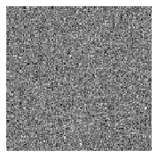

```python
inp = torch.randn(1,1,128,128)
show_image(inp[0]) # show image of random pixel intensity
```

```python
conv = nn.Conv2d(1,3, kernel_size=3)
pred = conv(inp)
pred.shape
```

```
torch.Size([1, 3, 126, 126])
```

```
Clipping input data to the valid range for imshow with RGB data ([0..1] for floats or [0..255] for integers).
```

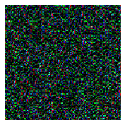

```python
show_image(pred[0])  # we mae image RGB, from 1 channel to 3 channels
```

```python
conv_next = nn.Conv2d(3,1,kernel_size=3)
pred_next = conv_next(pred)
pred_next.shape
```

```
torch.Size([1, 1, 124, 124])
```

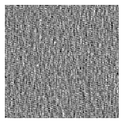

```python
show_image(pred_next[0])  # conver back to 1 channel by specifying channels
```

# Trick #34

PyTorch hooks #2 Take another look into pytorch hooks

```python
import torch
import torch.nn as nn
import torch.nn.init as init
from fastai.vision import children
```

```python
x = torch.randn(1,1,128,128) # one batch size, 128x128 image
```

```python
model = nn.Sequential(nn.Conv2d(1,3,kernel_size=3),nn.ReLU())
model
```

```
Sequential(
  (0): Conv2d(1, 3, kernel_size=(3, 3), stride=(1, 1))
  (1): ReLU()
)
```

```python
# initializing weights
def weight_init_orthogonal(m):
    classname = m.__class__.__name__
    print(classname)
    if classname.find("Conv") != -1:
        init.orthogonal_(m.weight.data, gain=1)

model.apply(weight_init_orthogonal)
```

```
Conv2d
ReLU
Sequential
```

```
Sequential(
  (0): Conv2d(1, 3, kernel_size=(3, 3), stride=(1, 1))
  (1): ReLU()
)
```

```python
# We want to see the output after our input is passed to Conv2d layer
# and then we will be able to pass it to any layer

# for saving feature after every layer by registering forawrd hook
class SaveFeature():
    feature=None

    # when we initialize, we register hook_fn on to the forward pass
    def __init__(self, m):
        self.hook = m.register_forward_hook(self.hook_fn)

    def hook_fn(self, module, input, output):
        self.features = output

    def close(self):
        self.hook.remove()
```

```python
# we have 2 children here: Conv2d and ReLU
# later we will be registering two different hooks on each
children(model)
```

```
[Conv2d(1, 3, kernel_size=(3, 3), stride=(1, 1)), ReLU()]
```

```python
saved_features_conv, saved_features_relu = SaveFeature(children(model)[0]), SaveFeature(children(model)[1])
```

```python
saved_features_conv.features # hook registered but nothing stored yet
```

```
---------------------------------------------------------------------------
AttributeError                            Traceback (most recent call last)
<ipython-input-15-be44644e2347> in <module>()
----> 1 saved_features_conv.features # hook registered but nothing stored yet

AttributeError: 'SaveFeature' object has no attribute 'features'
```

```python
# Let's run one forward pass
pred = model(x)
```

```python
saved_features_conv.features # output of conv layer in this forward pass is stored
```

```
tensor([[[[-2.5800, -0.2647,  1.6239,  ..., -0.2907,  0.1908,  0.7584],
          [ 0.0554, -1.1443, -1.1954,  ..., -1.0791, -1.3920,  0.0816],
          [-0.7532,  2.2206, -0.0770,  ...,  0.9156,  1.2014,  1.5768],
          ...,
          [-0.2323, -0.8035,  0.1890,  ..., -0.4978, -0.9132, -1.1315],
          [ 1.0107,  0.2377, -0.2464,  ..., -1.3003,  0.1436,  0.6211],
          [ 0.4233,  0.4291,  0.6064,  ...,  0.1020, -1.4040,  1.5670]],

         [[-0.8652, -1.9808,  0.6113,  ...,  0.5477, -1.1160, -0.3529],
          [ 1.3784, -2.6280, -0.6510,  ...,  0.0914, -0.2478, -1.0833],
          [ 0.5305,  0.2478,  1.9395,  ...,  0.3250, -0.1957, -1.1105],
          ...,
          [ 1.1443, -0.5373,  1.1536,  ..., -0.8420, -0.3519, -0.7982],
          [-0.0647,  0.2426, -1.6397,  ...,  0.5164,  0.9109,  0.7878],
          [-1.5264, -0.9349, -0.4995,  ..., -1.1442,  0.7425, -1.8948]],

         [[-0.5738,  0.8688,  1.2297,  ...,  0.0929,  1.1935,  0.9596],
          [-0.1158,  1.9589,  0.2431,  ...,  0.3384,  1.8386, -0.2965],
          [-0.0054,  0.6109, -0.2503,  ..., -0.7113,  0.6119,  1.0528],
          ...,
          [ 0.7711, -0.8947,  0.2121,  ...,  1.0238,  2.1332,  0.0358],
          [-1.2449,  0.3236, -0.4481,  ...,  1.0771,  0.4712,  0.3424],
          [-0.6949,  0.4338,  1.0977,  ..., -0.9355, -0.2789, -0.4622]]]],
       grad_fn=<MkldnnConvolutionBackward>)
```

```python
saved_features_conv.features.shape # check out the shape ofoutput of conv layer in this forward pass is stored
```

```
torch.Size([1, 3, 126, 126])
```

```python
saved_features_relu.features # features after forward pass
```

```
tensor([[[[0.0000, 0.0000, 1.6239,  ..., 0.0000, 0.1908, 0.7584],
          [0.0554, 0.0000, 0.0000,  ..., 0.0000, 0.0000, 0.0816],
          [0.0000, 2.2206, 0.0000,  ..., 0.9156, 1.2014, 1.5768],
          ...,
          [0.0000, 0.0000, 0.1890,  ..., 0.0000, 0.0000, 0.0000],
          [1.0107, 0.2377, 0.0000,  ..., 0.0000, 0.1436, 0.6211],
          [0.4233, 0.4291, 0.6064,  ..., 0.1020, 0.0000, 1.5670]],

         [[0.0000, 0.0000, 0.6113,  ..., 0.5477, 0.0000, 0.0000],
          [1.3784, 0.0000, 0.0000,  ..., 0.0914, 0.0000, 0.0000],
          [0.5305, 0.2478, 1.9395,  ..., 0.3250, 0.0000, 0.0000],
          ...,
          [1.1443, 0.0000, 1.1536,  ..., 0.0000, 0.0000, 0.0000],
          [0.0000, 0.2426, 0.0000,  ..., 0.5164, 0.9109, 0.7878],
          [0.0000, 0.0000, 0.0000,  ..., 0.0000, 0.7425, 0.0000]],

         [[0.0000, 0.8688, 1.2297,  ..., 0.0929, 1.1935, 0.9596],
          [0.0000, 1.9589, 0.2431,  ..., 0.3384, 1.8386, 0.0000],
          [0.0000, 0.6109, 0.0000,  ..., 0.0000, 0.6119, 1.0528],
          ...,
          [0.7711, 0.0000, 0.2121,  ..., 1.0238, 2.1332, 0.0358],
          [0.0000, 0.3236, 0.0000,  ..., 1.0771, 0.4712, 0.3424],
          [0.0000, 0.4338, 1.0977,  ..., 0.0000, 0.0000, 0.0000]]]],
       grad_fn=<ReluBackward0>)
```

```python
# we pass the output after first Conv Layer to another neural network
model2 = nn.Sequential(nn.Dropout(0.5))
```

```python
t = model2(saved_features_conv.features)
```

```python
t
```

```
tensor([[[[-5.1599, -0.0000,  3.2477,  ..., -0.5813,  0.0000,  0.0000],
          [ 0.0000, -0.0000, -0.0000,  ..., -2.1582, -0.0000,  0.1633],
          [-0.0000,  0.0000, -0.1541,  ...,  1.8312,  0.0000,  0.0000],
          ...,
          [-0.0000, -1.6069,  0.3780,  ..., -0.0000, -0.0000, -0.0000],
          [ 2.0213,  0.0000, -0.0000,  ..., -2.6007,  0.0000,  0.0000],
          [ 0.8467,  0.8583,  1.2128,  ...,  0.0000, -0.0000,  3.1339]],

         [[-1.7303, -0.0000,  0.0000,  ...,  0.0000, -2.2321, -0.0000],
          [ 0.0000, -5.2560, -1.3020,  ...,  0.1828, -0.0000, -0.0000],
          [ 1.0610,  0.0000,  3.8789,  ...,  0.6499, -0.3914, -2.2210],
          ...,
          [ 0.0000, -1.0745,  0.0000,  ..., -1.6841, -0.7037, -0.0000],
          [-0.0000,  0.0000, -3.2794,  ...,  1.0328,  0.0000,  0.0000],
          [-3.0527, -1.8698, -0.0000,  ..., -0.0000,  0.0000, -3.7897]],

         [[-1.1476,  0.0000,  0.0000,  ...,  0.1857,  2.3870,  1.9191],
          [-0.0000,  3.9178,  0.0000,  ...,  0.0000,  0.0000, -0.5930],
          [-0.0000,  1.2217, -0.0000,  ..., -1.4225,  0.0000,  0.0000],
          ...,
          [ 1.5422, -0.0000,  0.0000,  ...,  0.0000,  0.0000,  0.0716],
          [-2.4899,  0.6473, -0.8961,  ...,  0.0000,  0.0000,  0.0000],
          [-1.3897,  0.0000,  2.1954,  ..., -1.8710, -0.0000, -0.9243]]]],
       grad_fn=<MulBackward0>)
```

```python
t.shape
```

```
torch.Size([1, 3, 126, 126])
```

# Trick #35

step-by-step the computation of training neural_netwoks in PyTorch

```python
import torch
import torch.nn as nn
import torch.optim as optim
```

```python
inp = torch.ones(1, requires_grad=True) # input, a number whose value is one
inp
```

```
tensor([1.], requires_grad=True)
```

```python
outp = torch.zeros(1, requires_grad=True) # output, we want a number whose value is 0
outp
```

```
tensor([0.], requires_grad=True)
```

```python
x = nn.Linear(1,1) # we pass input to linear layer
```

```python
list(x.parameters())  # weights and bias of our linear layer, which we modify to get correct prediction
```

```
[Parameter containing:
 tensor([[0.0511]], requires_grad=True), Parameter containing:
 tensor([0.1359], requires_grad=True)]
```

```python
for t in x.parameters():
    print(t.grad) # now there is nothing stored
```

```
None
None
```

```python
# forward pass
pred = x(inp)
pred # we want pred to be zero (calculate loss with outp)
```

```
tensor([0.1870], grad_fn=<AddBackward0>)
```

```python
loss_function = nn.L1Loss()
```

```python
loss = loss_function(pred, outp)
```

```python
loss
```

```
tensor(0.1870, grad_fn=<MeanBackward0>)
```

```python
a = optim.SGD(x.parameters(), lr=0.01)
```

```python
a.zero_grad()
```

```python
for t in x.parameters():
    print(t.grad)
```

```
None
None
```

```python
loss.backward()
```

```python
loss # no change to the loss itself
```

```
tensor(0.1870, grad_fn=<MeanBackward0>)
```

```python
for t in x.parameters():
    print(t.grad)   # now gradients have been computed
```

```
tensor([[1.]])
tensor([1.])
```

```python
a.step() # update step
```

```python
list(x.parameters()) # weights have already been updated
```

```
[Parameter containing:
 tensor([[0.0411]], requires_grad=True), Parameter containing:
 tensor([0.1259], requires_grad=True)]
```

```python
for t in x.parameters():
    print(t.grad) # no change for gradient
```

```
tensor([[1.]])
tensor([1.])
```

Again

```python
pred = x(inp)
```

```python
pred
```

```
tensor([0.1670], grad_fn=<AddBackward0>)
```

```python
for t in x.parameters():
    print(t.grad)
```

```
tensor([[1.]])
tensor([1.])
```

```python
loss = loss_function(pred, outp)
loss
```

```
tensor(0.1670, grad_fn=<MeanBackward0>)
```

```python
a.zero_grad()
loss.backward()
```

```python
a.step()
```

```python
list(x.parameters())
```

```
[Parameter containing:
 tensor([[0.0311]], requires_grad=True), Parameter containing:
 tensor([0.1159], requires_grad=True)]
```

```python
for t in x.parameters():
    print(t.grad)
```

```
tensor([[1.]])
tensor([1.])
```

# Trick #36

# Trick #37

# Trick #38

# Trick #39

# Trick #40

# Trick #41

# Trick #42

# Trick #43

# Trick #44

# Trick #45

```python
# Trick #33
```